# Turnover covariate data prep

```r
library(data.table)
library(ggplot2)
library(beanplot) # for beanplots
library(gridExtra) # to combine ggplots together
library(grid) # to combine ggplots together


knitr::opts_knit$set(root.dir = rprojroot::find_rstudio_root_file()) # tell RStudio to use project root directory as the root for this notebook. Needed since we are storing code in a separate directory.
```

### Load data

```r
# BioTime
load('data/biotime_blowes/bt_malin.Rdata')
bt <- data.table(bt_malin); rm(bt_malin)

# Temperature average, trends, and seasonality
temperature <- fread('output/temperature_byrarefyID.csv.gz')

# microclimates
microclim <- fread('output/microclimates.csv.gz', drop = 1)

# NPP
npp <- fread('output/npplandocean.csv.gz')

# Body size
bs <- fread('output/mass_byrarefyid.csv.gz', drop = 1)
bs[, ':='(STUDY_ID = NULL, REALM = NULL, taxa_mod = NULL)] # remove unnecessary columns

# Mobility
speed <- fread('output/speed_byrarefyID.csv.gz', drop = 1)
speed[, ':='(STUDY_ID = NULL, REALM = NULL, taxa_mod = NULL)] # remove unnecessary columns

# Lifespan
lsp <- fread('output/lifespan_byrarefyID.csv.gz')

# CTI
cti <- fread('output/cti_byrarefyID.csv.gz')

# consumer vs. producer
cons <- fread('output/metab_feed_byspecies.csv.gz')
consfrac <- cons[, .(consfrac = sum(feeding == 'consumer')/.N), by = rarefyID] # fraction of species in each study that are consumers

# richness
rich <- fread('output/richness_by_rarefyID.csv.gz') # number of species

# endotherm vs. ectotherm
endo <- fread('output/metab_feed_byspecies.csv.gz') # endotherm vs. ectotherm classifications
endofrac <- endo[, .(endofrac = sum(metab != 'ecto')/.N), by = rarefyID]
rm(endo)

# human impact
human <- fread('output/humanimpact_by_rarefyID.csv.gz')

# %veg
veg <- readRDS('output/bt_malin_vct_uniqueID_stats.rds')
```

### Plot a turnover example

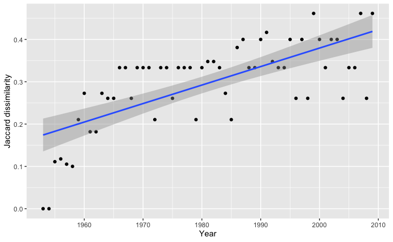

```r
#bt[, .(n = .N), by = rarefyID][n > 50,]

ggplot(bt[rarefyID == '339_1085477'], aes(YEAR, Jtu_base)) +
    geom_point() +
    geom_smooth(method = 'lm') +
    xlab('Year') + ylab('Jaccard dissimilarity')
```

### Assemble dataset of beta diversity trends (temporal turnover) and covariates

```r
# calculate temporal turnover
calctrend <- function(y, YEAR, nm = 'y'){ # function to calc trends
    mod <- lm(y ~ YEAR)
    out <- list(y = coef(mod)[2], # coef for the slope
         y_se = sqrt(diag(vcov(mod)))[2]) # SE
    names(out) <- c(nm, paste0(nm, '_se'))
    return(out)
}

setkey(bt, STUDY_ID, rarefyID, YEAR)
trends <- bt[, calctrend(Jtu_base, YEAR, 'Jtutrend'),
    by = .(REALM, Biome, taxa_mod, STUDY_ID, rarefyID, rarefyID_x, rarefyID_y)] # calculate trend in Jaccard turnover from first year, plus SEs
trends2 <- bt[, calctrend(Jbeta_base, YEAR, 'Jbetatrend'),
    by = .(rarefyID)] # calculate trend in total Jaccard' beta diversity's from first year,
```

```
essentially perfect fit: summary may be unreliableessentially perfect fit: summary may be unreliable
```

```r
trends3 <- bt[, calctrend(1-Horn_base, YEAR, 'Horntrend'),
    by = .(rarefyID)] # calculate trend in Horn-Morisita from first year. Convert to dissimilarity.
#trends4 <- bt[, .(Strend = coef(lm(I(log(S)) ~ YEAR))[2]), by = .(rarefyID)] # trend in log(S)
nyrBT <-  bt[, .(nyrBT = length(YEAR),
                 minyrBT = min(YEAR),
                 maxyrBT = max(YEAR),
                 medianyrBT = median(YEAR),
                 meanyrBT = mean(YEAR)),
             by = .(rarefyID)] # number of years in time-series

trends <- merge(trends, trends2) # merge in total J and Horn-Morisita
trends <- merge(trends, trends3)
#trends <- merge(trends, trends4)
trends <- merge(trends, nyrBT)
```

Add covariates

```r
# add covariates
trends <- merge(trends, temperature[, .(rarefyID, tempave, tempave_metab, temptrend, seas)], all.x = TRUE, by = 'rarefyID') # temperature ave, ave metabolic, trend, and seasonality
trends <- merge(trends, microclim[, .(rarefyID, microclim = Temp_sd20km)], all.x = TRUE, by = 'rarefyID') # microclimates
trends <- merge(trends, npp, all.x = TRUE, by = 'rarefyID') # npp
trends <- merge(trends, bs[, .(rarefyID, mass_mean_weight, mass_sd_weight)], all.x = TRUE) # body size mass (g)
trends <- merge(trends, speed[, .(rarefyID, speed_mean_weight, speed_sd_weight)], all.x = TRUE) # speed (km/hr)
trends <- merge(trends, lsp[, .(rarefyID, lifespan_mean_weight, lifespan_sd_weight)], all.x = TRUE) # lifespan (yr)
trends <- merge(trends, cti[, .(rarefyID, thermal_bias)], all.x = TRUE) # thermal bias (degC)
trends <- merge(trends, consfrac, all.x = TRUE) # fraction consumers
trends <- merge(trends, rich, all.x = TRUE) # species richness
trends <- merge(trends, endofrac, all.x = TRUE) # endotherm vs. ectotherm
trends <- merge(trends, human[, .(rarefyID, human_bowler = atc, human_venter = hfp, human_halpern = himp)], all.x = TRUE) # human impact
trends <- merge(trends, veg[, .(rarefyID, veg = veg)], all.x = TRUE) # vegetation index
trends[REALM == 'Marine', veg := 0] # veg index is 0 at sea
```

Do some basic checks

```r
# basic checks
trends
```

| rarefyID | REALM | Biome | taxa_mod | STUDY_ID | rarefyID_x | rarefyID_y | Jtutrend | Jtutrend_se | Jbetatrend | Jbetatrend_se | Horntrend | Horntrend_se | nyrBT | minyrBT | maxyrBT | medianyrBT | meanyrBT | tempave | tempave_metab | temptrend | seas | microclim | npp | mass_mean_weight | mass_sd_weight | speed_mean_weight | speed_sd_weight | lifespan_mean_weight | lifespan_sd_weight | … |
| --- | --- | --- | --- | --- | --- | --- | --- | --- | --- | --- | --- | --- | --- | --- | --- | --- | --- | --- | --- | --- | --- | --- | --- | --- | --- | --- | --- | --- | --- | --- |
| 100_606491 | Marine | Northern_European_Seas | Fish | 100 | -3.08000 | 51.14000 | 4.763952e-03 | 0.001601483 | 0.0048861863 | 0.001622134 | 3.100987e-03 | 1.568065e-03 | 31 | 1981 | 2011 | 1996.0 | 1996.000 | 12.05134963 | 12.05135 | 4.112933e-02 | 3.0760983 | 0.236038339 | 1685.9467 | 4.576354e+03 | 1.608100e+04 | 17.9017382 | 9.73094949 | 24.368790 | 13.85615611 | … |
| 101_606491 | Marine | Northern_European_Seas | Invertebrates | 101 | -3.08000 | 51.14000 | 0.000000e+00 | 0.000000000 | 0.0055735707 | 0.002121344 | 4.638415e-04 | 8.664591e-04 | 31 | 1981 | 2011 | 1996.0 | 1996.000 | 12.05134963 | 12.05135 | 4.112933e-02 | 3.0760983 | 0.236038339 | 1685.9467 | 1.546288e+01 | 6.575757e+01 | 39.2693489 | 19.97258766 | 6.855411 | 5.59543239 | … |
| 108_3933165 | Marine | Continental_High_Antarctic | Birds | 108 | 57.96500 | -65.28500 | 7.142857e-02 | NaN | 0.0714285714 | NaN | 7.142857e-02 | NaN | 2 | 1985 | 1999 | 1992.0 | 1992.000 | -1.32004129 | 40.00000 | -6.945833e-03 | 0.4808712 | 0.036479663 | 126.3856 | 1.011728e+03 | 6.624470e+02 | 0.4841773 | 0.13235876 | 2.322789 | 0.29626084 | … |
| 108_3941181 | Marine | Continental_High_Antarctic | Birds | 108 | 59.92750 | -66.29250 | 1.000000e-01 | NaN | 0.1071428571 | NaN | 1.147144e-01 | NaN | 2 | 1985 | 1993 | 1989.0 | 1989.000 | -1.27169187 | 40.00000 | -4.529737e-03 | 0.5261527 | 0.011864960 | 152.3814 | 3.802604e+02 | 3.606983e+02 | 0.8525844 | 0.44920780 | 1.835437 | 0.35873851 | … |
| 108_3941182 | Marine | Continental_High_Antarctic | Birds | 108 | 59.97000 | -66.19500 | 6.250000e-02 | NaN | 0.0892857143 | NaN | 8.782759e-02 | NaN | 2 | 1985 | 1993 | 1989.0 | 1989.000 | -1.27169187 | 40.00000 | -4.529737e-03 | 0.5261527 | 0.013156452 | 150.4591 | 2.559320e+03 | 2.480082e+03 | 4.7848882 | 5.41832941 | 2.628751 | 0.83131205 | … |
| 108_3941191 | Marine | Continental_High_Antarctic | Birds | 108 | 59.97500 | -65.29500 | 0.000000e+00 | NaN | 0.0370370370 | NaN | 1.128434e-02 | NaN | 2 | 1984 | 1993 | 1988.5 | 1988.500 | -1.26721012 | 40.00000 | -5.738948e-03 | 0.5261527 | 0.023989418 | 114.6438 | 1.182271e+03 | 1.159210e+03 | 0.4657148 | 0.13529451 | 2.374771 | 0.40861370 | … |
| 108_3941194 | Marine | Continental_High_Antarctic | Birds | 108 | 59.99000 | -64.98000 | 1.714286e-01 | NaN | 0.1777777778 | NaN | 1.171939e-01 | NaN | 2 | 1984 | 1989 | 1986.5 | 1986.500 | -0.98002931 | 39.77778 | -2.902485e-02 | 0.7776306 | 0.023052925 | 112.9365 | 8.314304e+03 | 5.010422e+04 | 1.0483901 | 2.52074277 | 2.589375 | 1.62314067 | … |
| 108_3943369 | Marine | Continental_High_Antarctic | Birds | 108 | 60.42750 | -66.33500 | 8.333333e-02 | NaN | 0.1093750000 | NaN | 4.342900e-02 | NaN | 2 | 1985 | 1993 | 1989.0 | 1989.000 | -1.27169187 | 39.75000 | -4.529737e-03 | 0.5261527 | 0.008500428 | 153.3760 | 2.727802e+06 | 4.906972e+06 | 1.1508810 | 0.84414495 | 7.180317 | 9.26730962 | … |
| 108_3945554 | Marine | Continental_High_Antarctic | Birds | 108 | 60.99500 | -66.75500 | 0.000000e+00 | NaN | 0.1250000000 | NaN | 3.196683e-01 | NaN | 2 | 1983 | 1985 | 1984.0 | 1984.000 | -1.23374892 | 40.00000 | 3.722021e-02 | 0.5261527 | 0.052701944 | 198.9637 | 3.079514e+03 | 8.756340e+03 | 2.4150408 | 3.76744780 | 2.344526 | 1.02212634 | … |
| 108_3945568 | Marine | Continental_High_Antarctic | Birds | 108 | 61.13500 | -65.33000 | 6.666667e-02 | NaN | 0.0666666667 | NaN | 2.766421e-02 | NaN | 2 | 1983 | 1989 | 1986.0 | 1986.000 | -1.27343011 | 39.60000 | -9.561809e-03 | 0.5241722 | 0.009339167 | 119.8733 | 1.064623e+04 | 5.532421e+04 | 1.2889044 | 1.28896522 | 2.130887 | 1.87328565 | … |

[output cut: 990 more lines]

```r
trends[, .(minJtu = min(Jtutrend), maxJtu = max(Jtutrend), minJbe = min(Jbetatrend), maxJbe = max(Jbetatrend),
           minHo = min(Horntrend, na.rm = TRUE), maxHo = max(Horntrend, na.rm = TRUE)), by = REALM]
```

| REALM | minJtu | maxJtu | minJbe | maxJbe | minHo | maxHo |
| --- | --- | --- | --- | --- | --- | --- |
| Marine | -0.10000000 | 0.5 | -0.08000000 | 0.5 | -0.09421855 | 0.5 |
| Terrestrial | -0.10000000 | 0.5 | -0.07142857 | 0.5 | -0.09373434 | 0.5 |
| Freshwater | -0.06666667 | 0.5 | -0.04166667 | 0.5 | -0.06129032 | 0.5 |

```r
trends[, .(nJtu = sum(Jtutrend < 0)), by = REALM] # why are some turnover trends < 0? first year more diverged than future years
```

| REALM | nJtu |
| --- | --- |
| Marine | 2891 |
| Terrestrial | 223 |
| Freshwater | 71 |

```r
trends[, .(nJ = sum(Jtutrend > 0)), by = REALM]
```

| REALM | nJ |
| --- | --- |
| Marine | 39219 |
| Terrestrial | 2854 |
| Freshwater | 693 |

```r
# number of species
trends[, summary(Nspp)]
```

```
   Min. 1st Qu.  Median    Mean 3rd Qu.    Max.
   1.00    6.00   11.00   19.35   24.00 1427.00
```

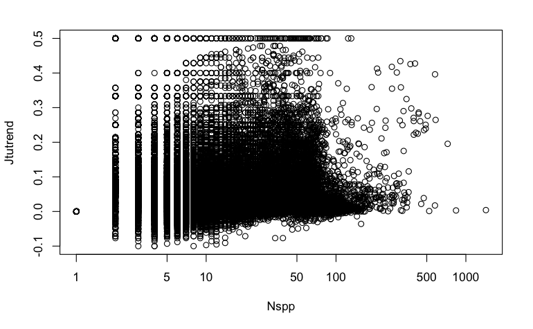

```r
trends[, plot(Nspp, Jtutrend, log = 'x')]
```

Remove studies with only 1 species

```r
nrow(trends)
```

```
[1] 53467
```

```r
trends <- trends[Nspp > 1, ]
nrow(trends)
```

```
[1] 53013
```

Turnover calculations are correlated, though less so for Horn

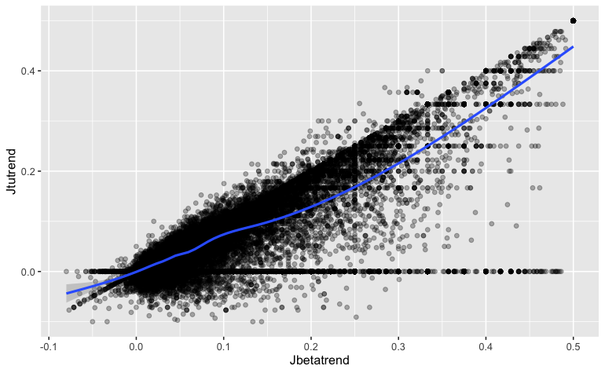

```r
# are turnover calculations correlated?
ggplot(trends, aes(Jbetatrend, Jtutrend)) +
    geom_point(alpha = 0.3) +
    geom_smooth()
```

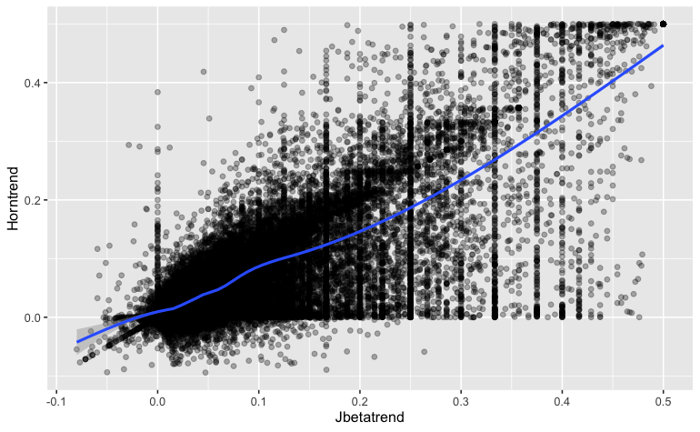

```r
ggplot(trends, aes(Jbetatrend, Horntrend)) +
    geom_point(alpha = 0.3) +
    geom_smooth()
```

## Compare covariates across realms

```r
i <- trends[, !duplicated(rarefyID)]; sum(i)
```

```
[1] 53013
```

```r
par(mfrow=c(5,3))
beanplot(rarefyID_y ~ REALM, data = trends[i,], what = c(1,1,1,1), col = c("#CAB2D6", "#33A02C", "#B2DF8A"), border = "#CAB2D6", ylab = 'Latitude (degN)', ll = 0.05)
beanplot(tempave ~ REALM, data = trends[i,], what = c(1,1,1,1), col = c("#CAB2D6", "#33A02C", "#B2DF8A"), border = "#CAB2D6", ylab = 'Temperature (degC)', ll = 0.05)
```

```r
beanplot(tempave_metab ~ REALM, data = trends[i,], what = c(1,1,1,1), col = c("#CAB2D6", "#33A02C", "#B2DF8A"), border = "#CAB2D6", ylab = 'Metabolic Temperature (degC)', ll = 0.05, bw = 'nrd0') # nrd0 bandwidth to calculation gap
beanplot(seas ~ REALM, data = trends[i,], what = c(1,1,1,1), col = c("#CAB2D6", "#33A02C", "#B2DF8A"), border = "#CAB2D6", ylab = 'Seasonality (degC)', ll = 0.05)
```

```r
beanplot(microclim ~ REALM, data = trends[i,], what = c(1,1,1,1), col = c("#CAB2D6", "#33A02C", "#B2DF8A"), border = "#CAB2D6", ylab = 'Microclimates (degC)', ll = 0.05)
```

```
log="y" selected
```

```r
beanplot(temptrend ~ REALM, data = trends[i,], what = c(1,1,1,1), col = c("#CAB2D6", "#33A02C", "#B2DF8A"), border = "#CAB2D6", ylab = 'Temperature trend (degC/yr)', ll = 0.05)
```

```r
beanplot(mass_mean_weight ~ REALM, data = trends[i,], what = c(1,1,1,1), col = c("#CAB2D6", "#33A02C", "#B2DF8A"), border = "#CAB2D6", ylab = 'Mass (g)', ll = 0.05, log = 'y')
beanplot(speed_mean_weight +1 ~ REALM, data = trends[i,], what = c(1,1,1,1), col = c("#CAB2D6", "#33A02C", "#B2DF8A"), border = "#CAB2D6", ylab = 'Speed (km/hr)', ll = 0.05, log = 'y')
```

```r
beanplot(lifespan_mean_weight ~ REALM, data = trends[i,], what = c(1,1,1,1), col = c("#CAB2D6", "#33A02C", "#B2DF8A"), border = "#CAB2D6", ylab = 'Lifespan (yr)', ll = 0.05, log = 'y')
#beanplot(consfrac ~ REALM, data = trends[i,], what = c(1,1,1,1), col = c("#CAB2D6", "#33A02C", "#B2DF8A"), border = "#CAB2D6", ylab = 'Consumers (fraction)', ll = 0.05, log = '') # too sparse
#beanplot(endofrac ~ REALM, data = trends[i,], what = c(1,1,1,1), col = c("#CAB2D6", "#33A02C", "#B2DF8A"), border = "#CAB2D6", ylab = 'Endotherms (fraction)', ll = 0.05, log = '') # too sparse
beanplot(Nspp ~ REALM, data = trends[i,], what = c(1,1,1,1), col = c("#CAB2D6", "#33A02C", "#B2DF8A"), border = "#CAB2D6", ylab = 'Number of species', ll = 0.05, log = 'y')
```

```r
beanplot(thermal_bias ~ REALM, data = trends[i & !is.na(thermal_bias),], what = c(1,1,1,1), col = c("#CAB2D6", "#33A02C", "#B2DF8A"), border = "#CAB2D6", ylab = 'Thermal bias (degC)', ll = 0.05)
beanplot(npp ~ REALM, data = trends[i,], what = c(1,1,1,1), col = c("#CAB2D6", "#33A02C", "#B2DF8A"), border = "#CAB2D6", ylab = 'NPP', ll = 0.05)
```

```
log="y" selected
```

```r
beanplot(veg ~ REALM, data = trends[i & REALM !='Marine',], what = c(1,1,1,1), col = c("#CAB2D6", "#33A02C", "#B2DF8A"), border = "#CAB2D6", ylab = 'NPP', ll = 0.05)
beanplot(human_bowler ~ REALM, data = trends[i,], what = c(1,1,1,1), col = c("#CAB2D6", "#33A02C", "#B2DF8A"), border = "#CAB2D6", ylab = 'Human impact score (Bowler)', ll = 0.05)
```

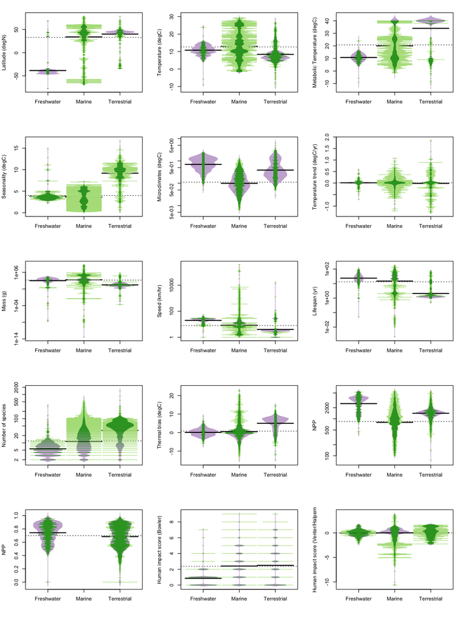

```r
beanplot(human_footprint.sc ~ REALM, data = trends[i,], what = c(1,1,1,1), col = c("#CAB2D6", "#33A02C", "#B2DF8A"), border = "#CAB2D6", ylab = 'Human impact score (Venter/Halpern', ll = 0.05)
```

Marine are in generally warmer locations (seawater doesn’t freeze) Marine have much lower seasonality. Marine and freshwater have some very small masses (plankton), but much of dataset is similar to terrestrial. Marine has a lot of slow, crawling organisms, but land has plants. Land also has birds (fast).

## Plot turnover vs. explanatory variables

Lines are ggplot smoother fits.

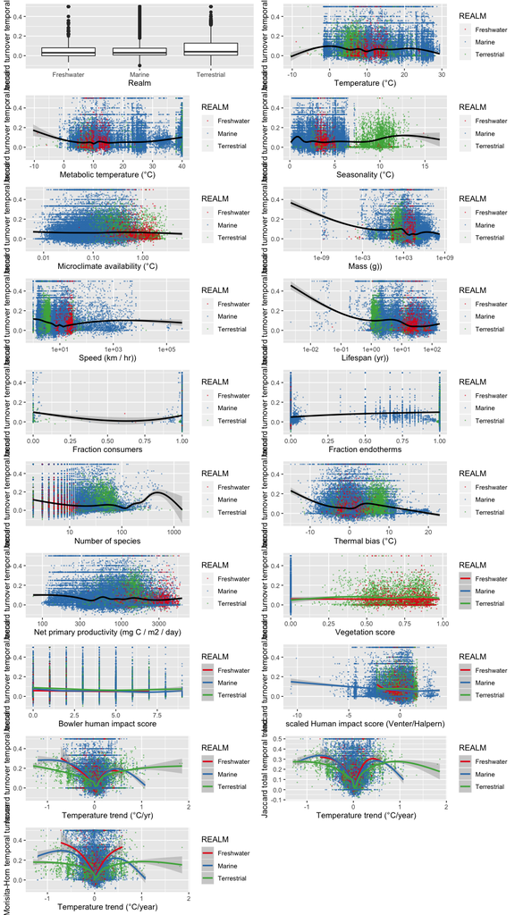

Strong trends with temperature change, but trends are pretty symmetric around no trend in temperature, which implies warming or cooling drives similar degree of community turnover. Some indication of less turnover for larger organisms (mass) Higher turnover on land with higher seasonality? More turnover for shorter-lived organisms? No really clear differences among realms.

### Write out

```r
write.csv(trends, gzfile('output/turnover_w_covariates.csv.gz'), row.names = FALSE)
```

### Useful variables

```r
# realm that combined Terrestrial and Freshwater, for interacting with human impact
trends[, REALM2 := REALM]
levels(trends$REALM2) = list(TerrFresh = "Freshwater", TerrFresh = "Terrestrial", Marine = "Marine")

# group Marine invertebrates/plants in with All
trends[, taxa_mod2 := taxa_mod]
trends[taxa_mod == 'Marine invertebrates/plants', taxa_mod2 := 'All']
```

### Log-transform some variables, then center and scale.

```r
trends[, tempave.sc := scale(tempave)]
trends[, tempave_metab.sc := scale(tempave_metab)]
trends[, seas.sc := scale(seas)]
trends[, microclim.sc := scale(log(microclim))]
trends[, temptrend.sc := scale(temptrend, center = FALSE)]
trends[, temptrend_abs.sc := scale(abs(temptrend), center = FALSE)] # do not center, so that 0 is still 0 temperature change
trends[, mass.sc := scale(log(mass_mean_weight))]
trends[, speed.sc := scale(log(speed_mean_weight+1))]
trends[, lifespan.sc := scale(log(lifespan_mean_weight))]
trends[, consumerfrac.sc := scale(consfrac)]
trends[, endothermfrac.sc := scale(endofrac)]
trends[, nspp.sc := scale(log(Nspp))]
trends[, thermal_bias.sc := scale(thermal_bias)]
trends[, npp.sc := scale(log(npp))]
trends[, veg.sc := scale(log(veg+1))]
trends[, human_bowler.sc := scale(log(human_bowler+1)), by = REALM2] # separate scaling by realm
trends[REALM2 == 'TerrFresh', human_footprint.sc := scale(log(human_venter+1))]
trends[REALM2 == 'Marine', human_footprint.sc := scale(log(human_halpern))]
```

### Do the variables look ok?

#### Unscaled

```r
# histograms to examine
cexmain = 0.6
par(mfrow = c(5,4))
invisible(trends[, hist(minyrBT, main = 'Start year', cex.main = cexmain)])
invisible(trends[, hist(maxyrBT - minyrBT, main = 'Duration (years)', cex.main = cexmain)])
invisible(trends[, hist(nyrBT, main = 'Number of sampled years', cex.main = cexmain)])
invisible(trends[, hist(mass_mean_weight, main = 'Mass (g)', cex.main = cexmain)])
invisible(trends[, hist(speed_mean_weight, main = 'Speed (km/hr)', cex.main = cexmain)])
invisible(trends[, hist(lifespan_mean_weight, main = 'Lifespan (yr)', cex.main = cexmain)])
invisible(trends[, hist(tempave_metab, main = 'Metabolic temperature (°C)', cex.main = cexmain)])
invisible(trends[, hist(consfrac, main = 'Consumers (fraction)', cex.main = cexmain)])
invisible(trends[, hist(endofrac, main = 'Endotherms (fraction)', cex.main = cexmain)])
invisible(trends[, hist(tempave, main = 'Environmental temperature (°C)', cex.main = cexmain)])
invisible(trends[, hist(temptrend, main = 'Temperature trend (°C/yr)', cex.main = cexmain)])
invisible(trends[, hist(seas, main = 'Seasonality (°C)', cex.main = cexmain)])
invisible(trends[, hist(microclim, main = 'Microclimates (°C)', cex.main = cexmain)])
invisible(trends[, hist(Nspp, main = 'Species richness', cex.main = cexmain)])
invisible(trends[, hist(thermal_bias, main = 'Thermal bias (°C)', cex.main = cexmain)])
invisible(trends[, hist(npp, main = 'Net primary productivity', cex.main = cexmain)])
invisible(trends[, hist(veg, main = 'Vegetation index', cex.main = cexmain)])
invisible(trends[, hist(human_bowler, main = 'Human impact score (Bowler)', cex.main = cexmain)])
invisible(trends[, hist(human_venter, main = 'Human impact score (Venter)', cex.main = cexmain)])
invisible(trends[, hist(human_halpern, main = 'Human impact score (Halpern)', cex.main = cexmain)])
```

#### Scaled

```r
# histograms to examine
cexmain = 0.6
par(mfrow = c(5,4))
invisible(trends[, hist(tempave.sc, main = 'Environmental temperature (°C)', cex.main = cexmain)])
invisible(trends[, hist(tempave_metab.sc, main = 'Metabolic temperature (°C)', cex.main = cexmain)])
invisible(trends[, hist(seas.sc, main = 'Seasonality (°C)', cex.main = cexmain)])
invisible(trends[, hist(microclim.sc, main = 'log Microclimates (°C)', cex.main = cexmain)])
invisible(trends[, hist(temptrend.sc, main = 'Temperature trend (°C/yr)', cex.main = cexmain)])
invisible(trends[, hist(temptrend_abs.sc, main = 'abs(Temperature trend) (°C/yr)', cex.main = cexmain)])
invisible(trends[, hist(mass.sc, main = 'log Mass (g)', cex.main = cexmain)])
invisible(trends[, hist(speed.sc, main = 'log Speed (km/hr)', cex.main = cexmain)])
invisible(trends[, hist(lifespan.sc, main = 'log Lifespan (yr)', cex.main = cexmain)])
invisible(trends[, hist(consumerfrac.sc, main = 'Consumers (fraction)', cex.main = cexmain)])
invisible(trends[, hist(endothermfrac.sc, main = 'Endotherms (fraction)', cex.main = cexmain)])
invisible(trends[, hist(nspp.sc, main = 'log Species richness', cex.main = cexmain)])
invisible(trends[, hist(thermal_bias.sc, main = 'Thermal bias (°C)', cex.main = cexmain)])
invisible(trends[, hist(npp.sc, main = 'log Net primary productivity', cex.main = cexmain)])
invisible(trends[, hist(veg.sc, main = 'log Vegetation index', cex.main = cexmain)])
invisible(trends[, hist(human_bowler.sc, main = 'log Human impact score (Bowler)', cex.main = cexmain)])
invisible(trends[, hist(human_footprint.sc, main = 'log Human impact score (Venter & Halpern)', cex.main = cexmain)])
```

### Check correlations among variables. Pearson’s r is on the lower diagonal.

```r
panel.cor <- function(x, y, digits = 2, prefix = "", cex.cor, ...)
{
    usr <- par("usr"); on.exit(par(usr))
    par(usr = c(0, 1, 0, 1))
    r <- cor(x, y, use = 'pairwise.complete.obs')
    txt <- format(c(r, 0.123456789), digits = digits)[1]
    txt <- paste0(prefix, txt)
    if(missing(cex.cor)) cex.cor <- 0.8/strwidth(txt)
    text(0.5, 0.5, txt) #, cex = cex.cor * r)
}
pairs(formula = ~ tempave.sc + tempave_metab.sc + seas.sc + microclim.sc + temptrend.sc + temptrend_abs.sc + mass.sc + speed.sc + lifespan.sc + consumerfrac.sc + endothermfrac.sc + nspp.sc + thermal_bias.sc + npp.sc + veg.sc + human_bowler.sc + human_footprint.sc, data = trends, gap = 1/10, cex = 0.2, col = '#00000022', lower.panel = panel.cor)
```